# Chapter 6 practice problems

## 6H1

```r
lds <- read_csv("../data/lds.csv")
data("WaffleDivorce")
d <- WaffleDivorce %>%
  left_join(lds, by = join_by(Location == state)) %>%
  mutate(perc_lds = str_remove(perc_lds, "%") %>% as.numeric()) %>%
  mutate(D = car::logit(Divorce),
         M = standardize(car::logit(Marriage)),
         A = standardize(MedianAgeMarriage),
         L = standardize(car::logit(perc_lds)),
         S = if_else(South == 1,2,1),
         W = standardize(WaffleHouses))
```

```
Note: largest value of p > 1 so values of p interpreted as percents
Note: largest value of p > 1 so values of p interpreted as percents
Note: largest value of p > 1 so values of p interpreted as percents
```

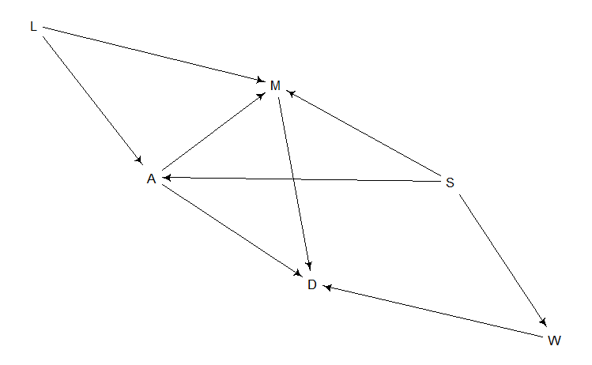

```r
sixm3 <- dagitty( "dag {
W[exposure]
D[outcome]
W -> D
W <- S -> A -> D
A <- L -> M
M -> D
A -> M
S -> M
}")
drawdag( sixm3)
```

```r
sixm3 %>% adjustmentSets(effect = "direct")
```

```
{ A, M }
{ S }
```

Based on this DAG, we have two options to estimate the effect of W on D:

1. D ~ W + S
2. D ~ W + A + M

I’ll build models based on both options to compare the effect of categorical vs continuous variables on estimate uncertainty.

```
2 vector or matrix parameters hidden. Use depth=2 to show them.
```

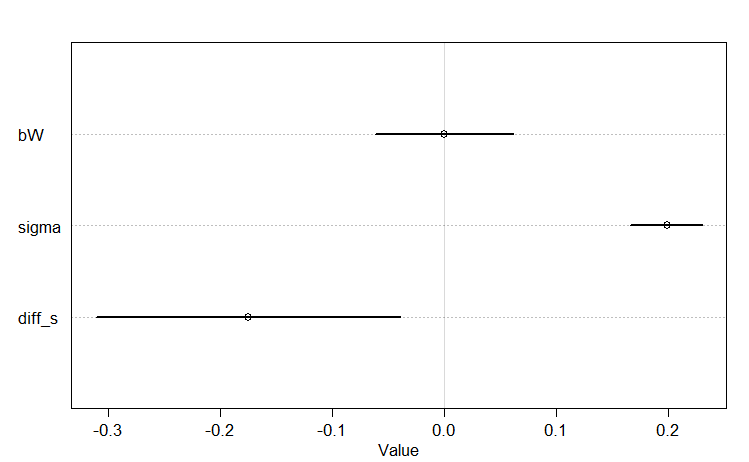

```r
m6h1.1 <- quap(
  alist(
    D ~ dnorm(mu,sigma),
    mu <- a[S] + bW * W,
    a[S] ~ dnorm(0,.5),
    bW ~ dnorm(0,.5),
    sigma ~ dexp(1)
    ),
  data = d
)

post <- extract.samples(m6h1.1)
post$diff_s <- post$a[,1]-post$a[,2]
plot(precis(post,pars = c("bW","diff_s")))
```

```r
precis(post, depth = 2)
```

```
quap posterior: 10000 samples from m6h1.1
```

|  | mean | sd | 5.5% | 94.5% | histogram |
| --- | --- | --- | --- | --- | --- |
| bW | 0.00 | 0.04 | -0.06 | 0.06 | ▁▁▂▇▇▂▁ |
| sigma | 0.20 | 0.02 | 0.17 | 0.23 | ▁▁▁▃▇▇▂▁▁ |
| a[1] | -2.29 | 0.04 | -2.34 | -2.23 | ▁▁▁▂▃▇▇▇▅▂▁▁▁▁ |
| a[2] | -2.11 | 0.07 | -2.22 | -2.00 | ▁▁▁▂▅▇▇▃▁▁▁ |
| diff_s | -0.18 | 0.08 | -0.31 | -0.04 | ▁▁▁▁▂▃▇▇▇▃▂▁▁▁ |

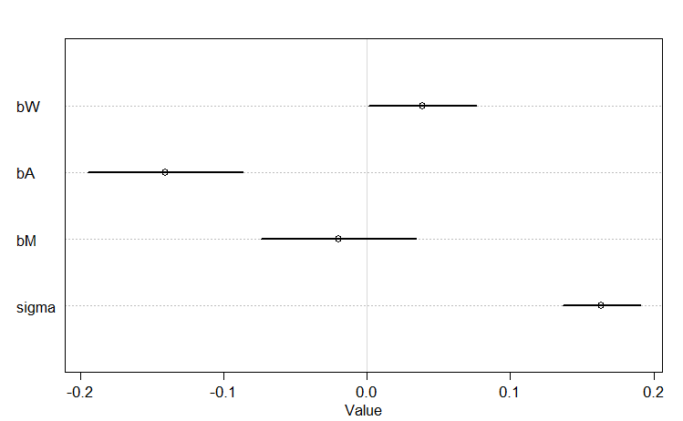

```r
m6h1.2 <- quap(
  alist(
    D ~ dnorm(mu,sigma),
    mu <- a + bW * W + bA* A + bM * M,
    a ~ dnorm(0,.2),
    bW ~ dnorm(0,.5),
    bA ~ dnorm(0,.5),
    bM ~ dnorm(0,.5),
    sigma ~ dexp(1)
    ),
  data = d
)

#plot(precis(c(post,m6h1.2),pars = c("diff_s","bW","bA","bM")))

plot(precis(m6h1.2), pars = c("bW","bA","bM","sigma"))
```

Something about conditioning on A and M may have opened a backdoor path that I didn’t anticipate, or failed to close a backdoor path (some other common cause of A, M, W - S?). With the underlying assumption that the right answer is no causal association, S appears to be the far better choice for closing backdoor paths.